# age_stimulation_plots

Gijsje

5/13/2021

# Load data

```r
metadata <- read.table("~/Documents/MiGASti/Databases/metadata.txt")
#set rownames to Sample
row.names(metadata) <- metadata$Sample
setwd("~/Documents/MiGASti/Databases")
#exclude samples that did not pass QC filtering
exclude <- read.table("samples2remove.txt")
exclude <- exclude$x
#Excludes the samples from filters.
#dim(genes_counts_filt)
metadata_filt = metadata[ !(rownames(metadata) %in% exclude), ]
length(metadata_filt)

#load gene matrix
load("~/Documents/MiGASti/Databases/gene_matrix.RData")
genes_counts_filt = genes_counts[, !colnames(genes_counts) %in% exclude]
#Excludes the samples from filters.
#dim(genes_counts_filt)
metadata_filt = metadata[ !(rownames(metadata) %in% exclude), ]
length(metadata_filt)
#remove low count genes
cpm <- cpm(genes_counts_filt)
# CPM >= 1 in at least 50% of the samples
keep.exp <- rowSums(cpm > 1) >= (0.5 * ncol(genes_counts_filt) )
genes_counts_filt1 <- genes_counts_filt[ keep.exp, ] #18997 genes
#order metadata and genes counts
genes_counts_ordered <- genes_counts_filt1[,rownames(metadata_filt)]
#head(genes_counts_ordered)
all(rownames(metadata_filt) == colnames (genes_counts_ordered)) #TRUE
```

# Metadata: Distribution of age in LPS and IFNy

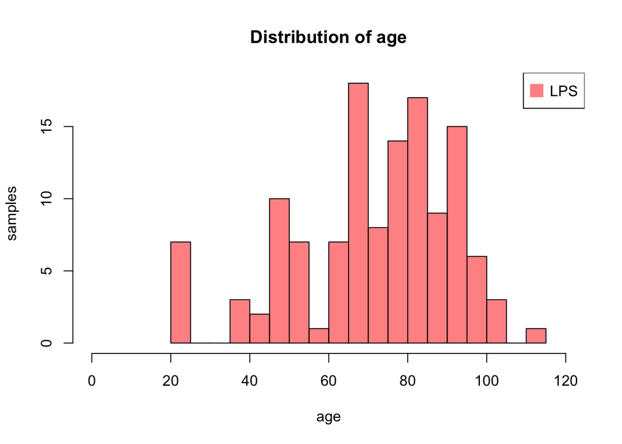

```r
#remove uncultured samples
metadata_cultured <- metadata_filt[metadata_filt$Stimulation != "ununstim",]
#check numbers
#dim(metadata_cultured)
#check numbers per stimulation
#table(metadata_filt$Stimulation)
#select only GFM samples in metadata
metadata_unstim = metadata_cultured[metadata_cultured$Stimulation=="unstim",]
metadata_LPS1 = metadata_cultured[metadata_cultured$Stimulation=="LPS",]
metadata_IFNy1 = metadata_cultured[metadata_cultured$Stimulation=="IFNy",]

set.seed(1)
LPS=metadata_LPS1$age
IFNy=metadata_IFNy1$age

# LPS distribution
hist(LPS, breaks=30, xlim=c(0,120), col=rgb(1,0,0,0.5), xlab="age",
     ylab="samples", main="Distribution of age" )
# Add legend
legend("topright", legend=c("LPS"), col=c(rgb(1,0,0,0.5),
     rgb(0,0,1,0.5)), pt.cex=2, pch=15 )
```

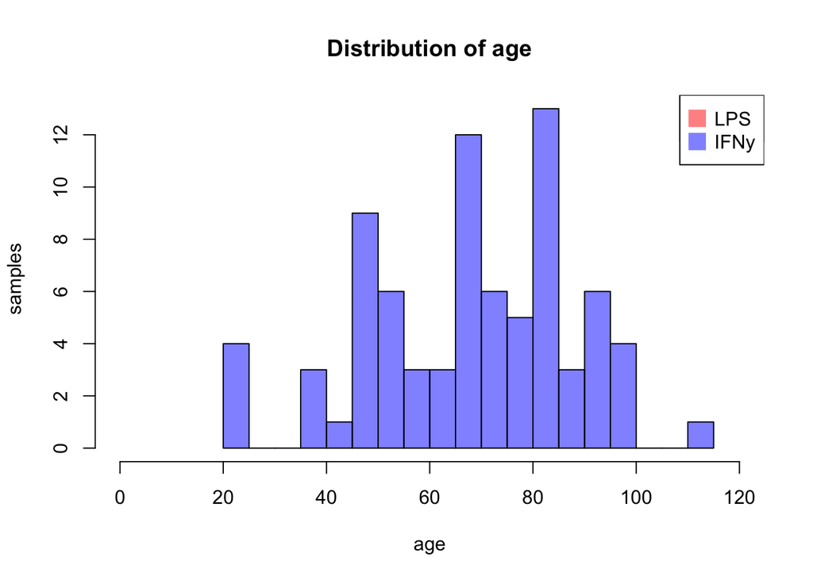

```r
# IFNy
hist(IFNy, breaks=30, xlim=c(0,120), col=rgb(0,0,1,0.5), xlab="age",
     ylab="samples", main="Distribution of age" )
# Add legend
legend("topright", legend=c("IFNy"), col=c(rgb(0,0,1,0.5),
     rgb(0,0,1,0.5)), pt.cex=2, pch=15 )


# Add legend
legend("topright", legend=c("LPS","IFNy"), col=c(rgb(1,0,0,0.5),
     rgb(0,0,1,0.5)), pt.cex=2, pch=15 )
```

# Aging in samples that are stimulated with LPS/IFNy? Does the immune response change in aging?

### Input: colMeans of the 6270 genes that respond to LPS in 128 LPS stimulated samples across aging

```r
#remove ununstim samples in metadata
metadata_cultured <- metadata_filt[metadata_filt$Stimulation != "ununstim",]
#check numbers
dim(metadata_cultured)
#check numbers per stimulation
table(metadata_filt$Stimulation)
#remove samples in genes counts datafile
genes_counts_cultured <- genes_counts_ordered[,metadata_cultured$Sample]
voom(genes_counts_cultured)
#table(metadata_filt$stimulation)
#length(metadata_cultured)

genes_counts_cultured <- cbind(ensembl = rownames(genes_counts_cultured), genes_counts_cultured)
genes_counts_cultured
rownames(genes_counts_cultured) <- NULL
```

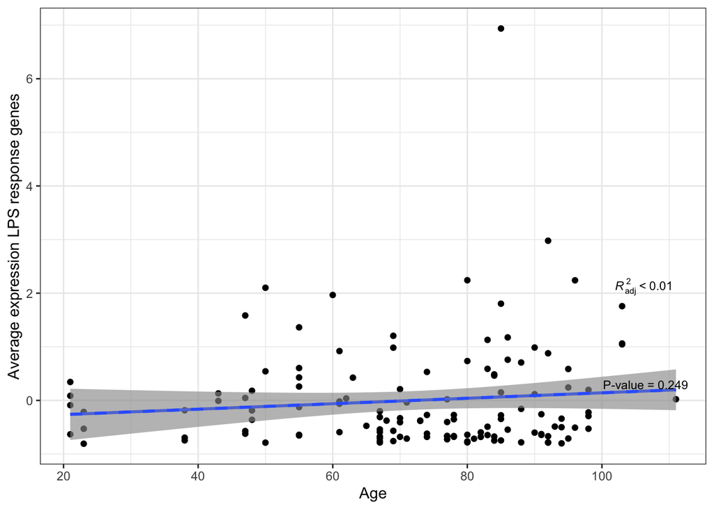

```r
#data load
load("~/Documents/MiGASti/docs/res_name_LPS2.Rdata")
load("~/Documents/MiGASti/docs/res_name_IFNy2.Rdata")
DEG_LPS <- subset(res_name_LPS2, adj.P.Val < 0.05)
DEG_IFNy <- subset(res_name_IFNy2, adj.P.Val < 0.05)

# select only sign LPS genes
LPS <- genes_counts_cultured[genes_counts_cultured$ensembl %in% DEG_LPS$ensembl, ]
#select only LPS samples
metadata_LPS = metadata_cultured[metadata_cultured$Stimulation=="LPS",]
#select only LPS samples in genes counts
LPS2 <-LPS[,metadata_LPS$Sample]
#order metadata and genes_counts
LPS_ordered <- LPS2[,rownames(metadata_LPS)]

#select only sign IFNy genes
IFNy <- genes_counts_cultured[genes_counts_cultured$ensembl %in% DEG_IFNy$ensembl, ]
#select only IFNy samples
metadata_IFNy = metadata_cultured[metadata_cultured$Stimulation=="IFNy",]
#select only IFNy samples in genes counts
IFNy2 <-IFNy[,metadata_IFNy$Sample]
#order metadata and genes_counts
IFNy_ordered <- IFNy[,rownames(metadata_IFNy)]

#create plot for LPS
LPS.mic <- data.frame(cbind(LPS = scale(colMeans(LPS_ordered)), Age = metadata_LPS$age))
colnames(LPS.mic) <- c("LPS", "Age")
library(ggpmisc)
formula <- y ~ x
ggplot(LPS.mic, aes_string(y = as.matrix(LPS.mic["LPS"]), x = as.matrix(LPS.mic["Age"]))) +
    geom_point() + scale_colour_gradient(low = "gray90", high = "black") + stat_smooth(method = lm) +
    theme_bw() + theme(plot.title = element_text(hjust = 0.5)) + geom_smooth(method = lm,
    linetype = "dashed") + labs(y = "Average expression LPS response genes", x = "Age") +
    stat_poly_eq(aes(label = c(paste(..adj.rr.label..))), label.x = "right", label.y = 0.37,
        formula = formula, parse = TRUE, size = 3) + # geom_cor(method='pearson')+
stat_fit_glance(method = "lm", method.args = list(formula = formula), geom = "text",
    aes(label = paste("P-value = ", signif(..p.value.., digits = 3), sep = "")),
    label.x = "right", label.y = 0.3, size = 3)
```

### Input: colMeans of the 658 genes that respond to IFNy in 79 IFNy stimulated samples across aging

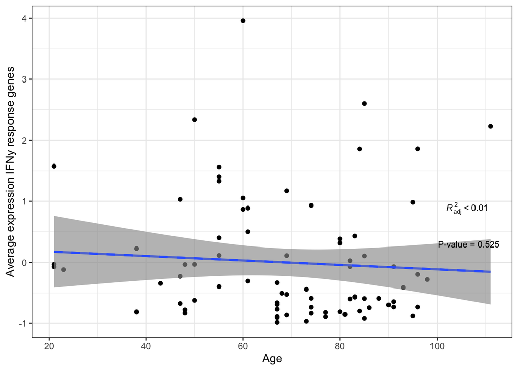

```r
IFNy.mic <- data.frame(cbind(IFNy = scale(colMeans(IFNy_ordered)), Age = metadata_IFNy$age))
colnames(IFNy.mic) <- c("IFNy", "Age")
library(ggpmisc)
formula <- y ~ x
ggplot(IFNy.mic, aes_string(y = as.matrix(IFNy.mic["IFNy"]), x = as.matrix(IFNy.mic["Age"]))) +
    geom_point() + scale_colour_gradient(low = "gray90", high = "black") + stat_smooth(method = lm) +
    theme_bw() + theme(plot.title = element_text(hjust = 0.5)) + geom_smooth(method = lm,
    linetype = "dashed") + labs(y = "Average expression IFNy response genes", x = "Age") +
    stat_poly_eq(aes(label = c(paste(..adj.rr.label..))), label.x = "right", label.y = 0.37,
        formula = formula, parse = TRUE, size = 3) + # geom_cor(method='pearson')+
stat_fit_glance(method = "lm", method.args = list(formula = formula), geom = "text",
    aes(label = paste("P-value = ", signif(..p.value.., digits = 3), sep = "")),
    label.x = "right", label.y = 0.3, size = 3)
```

# How many of the age related genes are in the stimulation genes?

#151 genes are both in aging dataset and LPS stimulation dataset #17 genes are both in aging dataset and IFNy stimulation dataset

```r
load("/Users/gijsjesnijders/Documents/MiGASti/Databases/res_age.Rdata")
load("~/Downloads/genes_counts_cultured.Rdata")
gencode_30 = read.table("~/Documents/MiGASti/Databases/ens.geneid.gencode.v30")
colnames(gencode_30) = c("ensembl","symbol")
res_age <- tibble::rownames_to_column(res_age, "ensembl")
res_name_age <- merge(res_age, gencode_30, by = "ensembl")
sign_age <- subset(res_age, adj.P.Val < 0.05)
length(rownames(sign_age))
```

```
## [1] 311
```

```r
load("~/Documents/MiGASti/docs/res_name_LPS2.Rdata")
load("~/Documents/MiGASti/docs/res_name_IFNy2.Rdata")
LPS2_overlap <- merge(DEG_LPS, sign_age, by = "ensembl")
length(LPS2_overlap$ensembl)
```

```
## [1] 151
```

```r
IFNy2_overlap <- merge(DEG_IFNy, sign_age, by = "ensembl")
length(IFNy2_overlap$ensembl)
```

```
## [1] 17
```

```r
list(LPS2_overlap$symbol)
```

```
## [[1]]
##   [1] "NIPAL3"     "MAD1L1"     "TFPI"       "CROT"       "CEACAM21"
##   [6] "MGST1"      "CD9"        "CCDC28A"    "TFB1M"      "PARP3"
##  [11] "YIPF1"      "AP3M2"      "ALDH3A2"    "CST7"       "BAX"
##  [16] "MT3"        "FUS"        "RGS1"       "TBC1D2"     "GCAT"
##  [21] "ABHD12"     "NDRG3"      "MAP1LC3A"   "PORCN"      "CDADC1"
##  [26] "RGCC"       "HMOX2"      "ETFB"       "ZNHIT1"     "SLC16A6"
##  [31] "WSB1"       "RAPGEF2"    "HTATIP2"    "ST3GAL4"    "CLEC2B"
##  [36] "LTA4H"      "VNN1"       "VNN2"       "SPARC"      "FRMD4B"
##  [41] "IL1A"       "TCEANC2"    "HMGCL"      "DPH5"       "MREG"
##  [46] "CRIPT"      "SIL1"       "RNF170"     "A1BG"       "LY9"
##  [51] "EREG"       "EMC3"       "IRF1"       "TNFSF14"    "PRDX5"
##  [56] "STYXL1"     "IFT22"      "LSP1"       "SYT4"       "DSTYK"
##  [61] "SLC39A11"   "TMEM106C"   "ANXA1"      "CYP27A1"    "NDUFB5"
##  [66] "IER3"       "C11orf1"    "PAQR5"      "UBL7"       "CPNE8"
```

[output cut: 17 more lines]

```r
list(IFNy2_overlap$symbol)
```

```
## [[1]]
##  [1] "CD9"       "RGCC"      "TRIM16L"   "CLEC2B"    "EREG"      "IRF1"
##  [7] "CYP27A1"   "FCMR"      "AIM2"      "IL15"      "CDYL2"     "ARL4C"
## [13] "SLC29A3"   "TRIM16"    "LINC00996" "APOBEC3C"  "HCAR3"
```

### Aging in samples that are stimulated with LPS and known to show effect in aging and after LPS stimulation? Does the immune response change in aging?

#Input: colMeans of the 151 genes that respond to LPS and are found to be differentially expressed in aging in 128 LPS stimulated samples across aging

```r
#remove ununstim samples in metadata
metadata_cultured <- metadata_filt[metadata_filt$Stimulation != "ununstim",]
#check numbers
dim(metadata_cultured)
#check numbers per stimulation
table(metadata_filt$Stimulation)
#remove samples in genes counts datafile
genes_counts_cultured <- genes_counts_ordered[,metadata_cultured$Sample]
voom(genes_counts_cultured)
#table(metadata_filt$stimulation)
#length(metadata_cultured)


genes_counts_cultured <- cbind(ensembl = rownames(genes_counts_cultured), genes_counts_cultured)
genes_counts_cultured
rownames(genes_counts_cultured) <- NULL
```

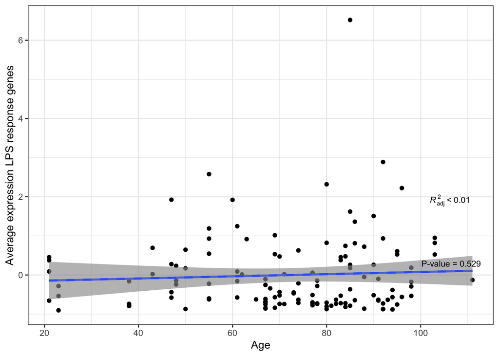

```r
LPS <- genes_counts_cultured[genes_counts_cultured$ensembl %in% LPS2_overlap$ensembl, ]
#select only LPS samples
metadata_LPS = metadata_cultured[metadata_cultured$Stimulation=="LPS",]
#select only LPS samples in genes counts
LPS2 <-LPS[,metadata_LPS$Sample]
#order metadata and genes_counts
LPS_ordered <- LPS[,rownames(metadata_LPS)]

LPS.mic <- data.frame(cbind(LPS = scale(colMeans(LPS_ordered)), Age = metadata_LPS$age))
colnames(LPS.mic) <- c("LPS", "Age")
library(ggpmisc)
formula <- y ~ x
ggplot(LPS.mic, aes_string(y = as.matrix(LPS.mic["LPS"]), x = as.matrix(LPS.mic["Age"]))) +
    geom_point() + scale_colour_gradient(low = "gray90", high = "black") + stat_smooth(method = lm) +
    theme_bw() + theme(plot.title = element_text(hjust = 0.5)) + geom_smooth(method = lm,
    linetype = "dashed") + labs(y = "Average expression LPS response genes", x = "Age") +
    stat_poly_eq(aes(label = c(paste(..adj.rr.label..))), label.x = "right", label.y = 0.37,
        formula = formula, parse = TRUE, size = 3) + # geom_cor(method='pearson')+
stat_fit_glance(method = "lm", method.args = list(formula = formula), geom = "text",
    aes(label = paste("P-value = ", signif(..p.value.., digits = 3), sep = "")),
    label.x = "right", label.y = 0.3, size = 3)
```

### Aging in samples that are stimulated with IFNy and known to show effect in aging and after IFNy stimulation? Does the immune response change in aging?

```r
#remove ununstim samples in metadata
metadata_cultured <- metadata_filt[metadata_filt$Stimulation != "ununstim",]
#check numbers
dim(metadata_cultured)
#check numbers per stimulation
table(metadata_filt$Stimulation)
#remove samples in genes counts datafile
genes_counts_cultured <- genes_counts_ordered[,metadata_cultured$Sample]
voom(genes_counts_cultured)
#table(metadata_filt$stimulation)
#length(metadata_cultured)


genes_counts_cultured <- cbind(ensembl = rownames(genes_counts_cultured), genes_counts_cultured)
genes_counts_cultured
rownames(genes_counts_cultured) <- NULL
```

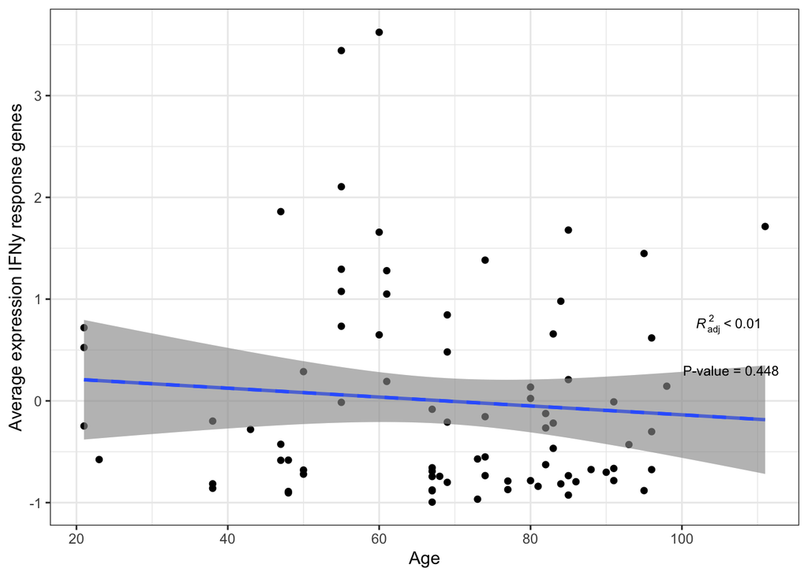

```r
IFNy <- genes_counts_cultured[genes_counts_cultured$ensembl %in% IFNy2_overlap$ensembl, ]
#select only IFNy samples
metadata_IFNy = metadata_cultured[metadata_cultured$Stimulation=="IFNy",]
#select only IFNy samples in genes counts
IFNy2 <-IFNy[,metadata_IFNy$Sample]
#order metadata and genes_counts
IFNy_ordered <- IFNy[,rownames(metadata_IFNy)]

IFNy.mic <- data.frame(cbind(IFNy = scale(colMeans(IFNy_ordered)), Age = metadata_IFNy$age))
colnames(IFNy.mic) <- c("IFNy", "Age")
library(ggpmisc)
formula <- y ~ x
ggplot(IFNy.mic, aes_string(y = as.matrix(IFNy.mic["IFNy"]), x = as.matrix(IFNy.mic["Age"]))) +
    geom_point() + scale_colour_gradient(low = "gray90", high = "black") + stat_smooth(method = lm) +
    theme_bw() + theme(plot.title = element_text(hjust = 0.5)) + geom_smooth(method = lm,
    linetype = "dashed") + labs(y = "Average expression IFNy response genes", x = "Age") +
    stat_poly_eq(aes(label = c(paste(..adj.rr.label..))), label.x = "right", label.y = 0.37,
        formula = formula, parse = TRUE, size = 3) + # geom_cor(method='pearson')+
stat_fit_glance(method = "lm", method.args = list(formula = formula), geom = "text",
    aes(label = paste("P-value = ", signif(..p.value.., digits = 3), sep = "")),
    label.x = "right", label.y = 0.3, size = 3)
```